# Part I - (Ford GoBike System Data )

## Preliminary Wrangling

```python
# import all packages and set plots to be embedded inline
import numpy as np
import pandas as pd
import matplotlib.pyplot as plt
import seaborn as sns
```

```python
rides_df=pd.read_csv('201902-fordgobike-tripdata.csv')
```

```python
rides_df.shape
```

```
(183412, 16)
```

```python
rides_df.dtypes
```

```
duration_sec                 int64
start_time                  object
end_time                    object
start_station_id           float64
start_station_name          object
start_station_latitude     float64
start_station_longitude    float64
end_station_id             float64
end_station_name            object
end_station_latitude       float64
end_station_longitude      float64
bike_id                      int64
user_type                   object
member_birth_year          float64
member_gender               object
bike_share_for_all_trip     object
dtype: object
```

```python
rides_df.head()
```

|  | duration_sec | start_time | end_time | start_station_id | start_station_name | start_station_latitude | start_station_longitude | end_station_id | end_station_name | end_station_latitude | end_station_longitude | bike_id | user_type | member_birth_year | member_gender | bike_share_for_all_trip |
| --- | --- | --- | --- | --- | --- | --- | --- | --- | --- | --- | --- | --- | --- | --- | --- | --- |
| 0 | 52185 | 2019-02-28 17:32:10.1450 | 2019-03-01 08:01:55.9750 | 21.0 | Montgomery St BART Station (Market St at 2nd St) | 37.789625 | -122.400811 | 13.0 | Commercial St at Montgomery St | 37.794231 | -122.402923 | 4902 | Customer | 1984.0 | Male | No |
| 1 | 42521 | 2019-02-28 18:53:21.7890 | 2019-03-01 06:42:03.0560 | 23.0 | The Embarcadero at Steuart St | 37.791464 | -122.391034 | 81.0 | Berry St at 4th St | 37.775880 | -122.393170 | 2535 | Customer | NaN | NaN | No |
| 2 | 61854 | 2019-02-28 12:13:13.2180 | 2019-03-01 05:24:08.1460 | 86.0 | Market St at Dolores St | 37.769305 | -122.426826 | 3.0 | Powell St BART Station (Market St at 4th St) | 37.786375 | -122.404904 | 5905 | Customer | 1972.0 | Male | No |
| 3 | 36490 | 2019-02-28 17:54:26.0100 | 2019-03-01 04:02:36.8420 | 375.0 | Grove St at Masonic Ave | 37.774836 | -122.446546 | 70.0 | Central Ave at Fell St | 37.773311 | -122.444293 | 6638 | Subscriber | 1989.0 | Other | No |
| 4 | 1585 | 2019-02-28 23:54:18.5490 | 2019-03-01 00:20:44.0740 | 7.0 | Frank H Ogawa Plaza | 37.804562 | -122.271738 | 222.0 | 10th Ave at E 15th St | 37.792714 | -122.248780 | 4898 | Subscriber | 1974.0 | Male | Yes |

### What is the structure of your dataset?

> The dataset has records for 183412 individual rides. The dataset has 16 different features

### What is/are the main feature(s) of interest in your dataset?

> The main features in this dataset is the ride duration in seconds, user type, member age, active week days

### What features in the dataset do you think will help support your investigation into your feature(s) of interest?

> The main features in this dataset is the ride duration in seconds, user type, member age, user gender, location of start and end stations, start and end time ,bike id, start_time

## Question-Visualization-Observations

### Question-1 : which user type has the highest number of rides?

```python
rides_df['user_type'].unique()
```

```
array(['Customer', 'Subscriber'], dtype=object)
```

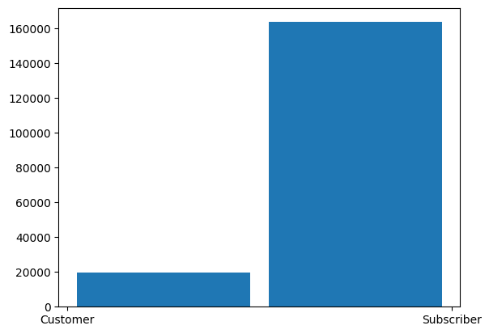

```python
plt.hist(rides_df['user_type'],bins=2,rwidth=0.9);
```

### Observation : Number of rides taken by subscribers is way more than rides taken by customers who do not have subscription

### Question-2 : Which age groups take the highest /lowest number of rides?

> To answer this question I need to do feature engineering, I need to create another variable (Age) that is calculated using the Year of birth

```python
import datetime
# Get the current year as a float
current_year= float(datetime.datetime.now().year)
rides_df['age']=(current_year-rides_df['member_birth_year'])
```

```python
rides_df['age'].describe()
```

```
count    175147.000000
mean         39.193563
std          10.116689
min          23.000000
25%          32.000000
50%          37.000000
75%          44.000000
max         146.000000
Name: age, dtype: float64
```

```python
count_over_100=len(rides_df[rides_df['age']>105])
total_count=len(rides_df)
print("percentage of people over 100 is ",(count_over_100/total_count))
```

```
percentage of people over 100 is  0.0003925588293023357
```

#### Observation : Percentage of peope whose age is over 105 is 0.000392

#### Decision : Droping records for people whose age is over 105

```python
rides_df.drop(rides_df[rides_df['age']>105].index,inplace=True)
```

```python
rides_df['age'].describe()
```

```
count    175075.000000
mean         39.158778
std           9.972079
min          23.000000
25%          32.000000
50%          37.000000
75%          44.000000
max         104.000000
Name: age, dtype: float64
```

```python
rides_df['age'].isna().sum()/len(rides_df)
```

```
0.04508017890258536
```

#### 4% of data has empty age

## Fill na with the average age

```python
rides_df['age'].fillna(rides_df['age'].mean(),inplace=True)
```

```python
rides_df['age'].isna().sum()
```

```
0
```

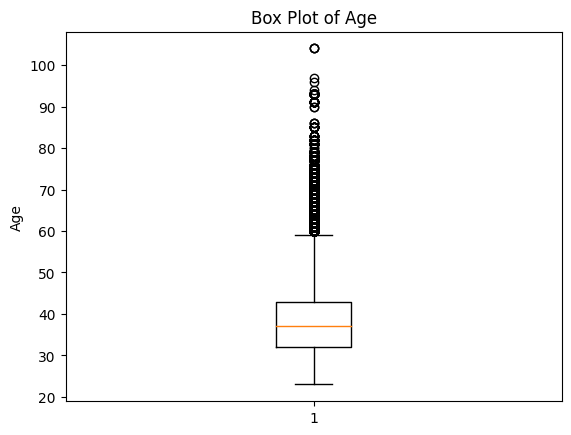

```python
# Box plot for 'Age' column
plt.boxplot(rides_df['age'])

# Label the plot
plt.title('Box Plot of Age')
plt.ylabel('Age')

# Show the plot
plt.show()
```

#### Ages will be classified to age groups as follow :

20 - 29 , 30 - 35 ,36 - 40,41 - 50,51 -60 ,over 60

```python
# Define a function to categorize age into groups
def categorize_age(age):
    if 20 <= age <= 29:
        return '20-29'
    elif 30 <= age <= 35:
        return '30-35'
    elif 36 <= age <= 40:
        return '36-40'
    elif 41 <= age <= 50:
        return '41-50'
    elif 51 <= age <= 60:
        return '51-60'
    else:
        return 'over 60'
```

```python
# Apply the function to the 'Age' column
rides_df['age_group'] = rides_df['age'].apply(categorize_age)
```

```python
age_bar=rides_df['age_group'].value_counts().reset_index()
```

```python
age_bar
```

|  | index | age_group |
| --- | --- | --- |
| 0 | 30-35 | 51363 |
| 1 | 36-40 | 48082 |
| 2 | 41-50 | 37202 |
| 3 | 20-29 | 22992 |
| 4 | 51-60 | 15884 |
| 5 | over 60 | 7817 |

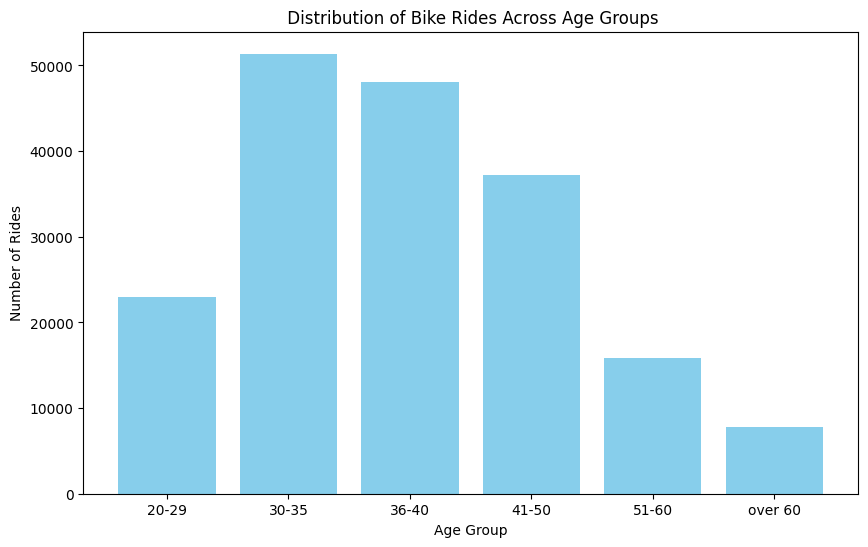

```python
# Define the order of categories
category_order = ['20-29','30-35','36-40','41-50','51-60','over 60']

# Convert the 'Category' column to a categorical type with specified order
age_bar['index'] = pd.Categorical(age_bar['index'], categories=category_order, ordered=True)
# Sort the DataFrame based on the categorical order
age_bar = age_bar.sort_values('index')

# Create a bar chart
plt.figure(figsize=(10, 6))  # Optional: set figure size
plt.bar(age_bar['index'], age_bar['age_group'], color='skyblue')

# Label the plot
plt.xlabel('Age Group')
plt.ylabel('Number of Rides')
plt.title(' Distribution of Bike Rides Across Age Groups')

# Show the plot
plt.show()
```

#### Observation : The majority of the rides were taken by people aged between 30 and 40. The number of rides by people over 60 is the least.

### Question 3 : What is the ride duration ditribution

```python
rides_df['duration_hour']=rides_df['duration_sec']/60/60
```

```python
rides_df['duration_hour'].describe()
```

```
count    183340.000000
mean          0.201696
std           0.498533
min           0.016944
25%           0.090278
50%           0.142778
75%           0.221111
max          23.734444
Name: duration_hour, dtype: float64
```

```python
count_duration_hours_over_5 = rides_df[rides_df['duration_hour'] > .2].count()
```

```python
rides_df['duration_hour'].mean()
```

```
0.20169605953722897
```

### The histoogram was highly skewed (many small values), this is why I applied logarithmic scaling to the X-axis (Duration in hours)

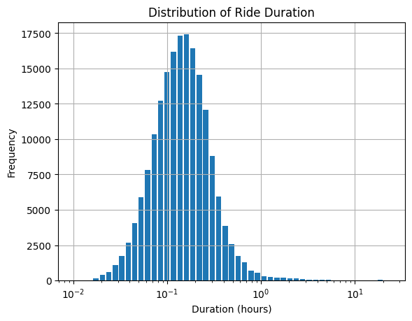

```python
rides_df['duration_hour'].hist(bins=np.logspace(np.log10(0.01), np.log10(23.7), 50), rwidth=0.8)
plt.xscale('log')  # Logarithmic scale on x-axis
plt.xlabel('Duration (hours)')
plt.ylabel('Frequency')
plt.title('Distribution of Ride Duration')

plt.show()
```

#### Observation :

10^0 = 1 (hour) , 10^−1=0.1 hour , 10^−2=0.01 , 10^1=10 ,10^2=100

### Discuss the distribution(s) of your variable(s) of interest. Were there any unusual points? Did you need to perform any transformations?

> I calculate age from the year of birth. In the new age column, 4% of ages were empty, I filled them with average age. I classify ages into age groups to make visualization easier

> Subscribers in the dataset outnumbers customers

## Bivariate Exploration

#### Question-3 : How does the riding bikes differ between subscribers and non-members in terms of ride duration?

```python
rides_df
```

|  | duration_sec | start_time | end_time | start_station_id | start_station_name | start_station_latitude | start_station_longitude | end_station_id | end_station_name | end_station_latitude | end_station_longitude | bike_id | user_type | member_birth_year | member_gender | bike_share_for_all_trip | age | age_group | duration_hour |
| --- | --- | --- | --- | --- | --- | --- | --- | --- | --- | --- | --- | --- | --- | --- | --- | --- | --- | --- | --- |
| 0 | 52185 | 2019-02-28 17:32:10.1450 | 2019-03-01 08:01:55.9750 | 21.0 | Montgomery St BART Station (Market St at 2nd St) | 37.789625 | -122.400811 | 13.0 | Commercial St at Montgomery St | 37.794231 | -122.402923 | 4902 | Customer | 1984.0 | Male | No | 40.000000 | 36-40 | 14.495833 |
| 1 | 42521 | 2019-02-28 18:53:21.7890 | 2019-03-01 06:42:03.0560 | 23.0 | The Embarcadero at Steuart St | 37.791464 | -122.391034 | 81.0 | Berry St at 4th St | 37.775880 | -122.393170 | 2535 | Customer | NaN | NaN | No | 39.158778 | 36-40 | 11.811389 |
| 2 | 61854 | 2019-02-28 12:13:13.2180 | 2019-03-01 05:24:08.1460 | 86.0 | Market St at Dolores St | 37.769305 | -122.426826 | 3.0 | Powell St BART Station (Market St at 4th St) | 37.786375 | -122.404904 | 5905 | Customer | 1972.0 | Male | No | 52.000000 | 51-60 | 17.181667 |
| 3 | 36490 | 2019-02-28 17:54:26.0100 | 2019-03-01 04:02:36.8420 | 375.0 | Grove St at Masonic Ave | 37.774836 | -122.446546 | 70.0 | Central Ave at Fell St | 37.773311 | -122.444293 | 6638 | Subscriber | 1989.0 | Other | No | 35.000000 | 30-35 | 10.136111 |
| 4 | 1585 | 2019-02-28 23:54:18.5490 | 2019-03-01 00:20:44.0740 | 7.0 | Frank H Ogawa Plaza | 37.804562 | -122.271738 | 222.0 | 10th Ave at E 15th St | 37.792714 | -122.248780 | 4898 | Subscriber | 1974.0 | Male | Yes | 50.000000 | 41-50 | 0.440278 |
| ... | ... | ... | ... | ... | ... | ... | ... | ... | ... | ... | ... | ... | ... | ... | ... | ... | ... | ... | ... |
| 183407 | 480 | 2019-02-01 00:04:49.7240 | 2019-02-01 00:12:50.0340 | 27.0 | Beale St at Harrison St | 37.788059 | -122.391865 | 324.0 | Union Square (Powell St at Post St) | 37.788300 | -122.408531 | 4832 | Subscriber | 1996.0 | Male | No | 28.000000 | 20-29 | 0.133333 |
| 183408 | 313 | 2019-02-01 00:05:34.7440 | 2019-02-01 00:10:48.5020 | 21.0 | Montgomery St BART Station (Market St at 2nd St) | 37.789625 | -122.400811 | 66.0 | 3rd St at Townsend St | 37.778742 | -122.392741 | 4960 | Subscriber | 1984.0 | Male | No | 40.000000 | 36-40 | 0.086944 |
| 183409 | 141 | 2019-02-01 00:06:05.5490 | 2019-02-01 00:08:27.2200 | 278.0 | The Alameda at Bush St | 37.331932 | -121.904888 | 277.0 | Morrison Ave at Julian St | 37.333658 | -121.908586 | 3824 | Subscriber | 1990.0 | Male | Yes | 34.000000 | 30-35 | 0.039167 |
| 183410 | 139 | 2019-02-01 00:05:34.3600 | 2019-02-01 00:07:54.2870 | 220.0 | San Pablo Ave at MLK Jr Way | 37.811351 | -122.273422 | 216.0 | San Pablo Ave at 27th St | 37.817827 | -122.275698 | 5095 | Subscriber | 1988.0 | Male | No | 36.000000 | 36-40 | 0.038611 |
| 183411 | 271 | 2019-02-01 00:00:20.6360 | 2019-02-01 00:04:52.0580 | 24.0 | Spear St at Folsom St | 37.789677 | -122.390428 | 37.0 | 2nd St at Folsom St | 37.785000 | -122.395936 | 1057 | Subscriber | 1989.0 | Male | No | 35.000000 | 30-35 | 0.075278 |

183340 rows × 19 columns

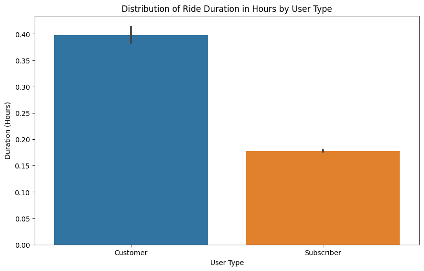

```python
plt.figure(figsize=(10, 6))
sns.barplot(x='user_type', y='duration_hour', data=rides_df)

# Add labels and title
plt.xlabel('User Type')
plt.ylabel('Duration (Hours)')
plt.title('Distribution of Ride Duration in Hours by User Type')
```

#### Observation :Unsubscribed customers (non-members) tend to spend a longer duration on a single ride compared to subscribers. This suggests that subscribers typically use the bike for any journey even if it is short, while non-members often take the bike for long rides.

#### Question 4 :What is the day of the week where there is maximum number of rides

```python
rides_df.info()
```

```
<class 'pandas.core.frame.DataFrame'>
Int64Index: 183340 entries, 0 to 183411
Data columns (total 19 columns):
 #   Column                   Non-Null Count   Dtype
---  ------                   --------------   -----
 0   duration_sec             183340 non-null  int64
 1   start_time               183340 non-null  object
 2   end_time                 183340 non-null  object
 3   start_station_id         183143 non-null  float64
 4   start_station_name       183143 non-null  object
 5   start_station_latitude   183340 non-null  float64
 6   start_station_longitude  183340 non-null  float64
 7   end_station_id           183143 non-null  float64
 8   end_station_name         183143 non-null  object
 9   end_station_latitude     183340 non-null  float64
 10  end_station_longitude    183340 non-null  float64
 11  bike_id                  183340 non-null  int64
 12  user_type                183340 non-null  object
 13  member_birth_year        175075 non-null  float64
 14  member_gender            175075 non-null  object
 15  bike_share_for_all_trip  183340 non-null  object
 16  age                      183340 non-null  float64
 17  age_group                183340 non-null  object
 18  duration_hour            183340 non-null  float64
dtypes: float64(9), int64(2), object(8)
memory usage: 28.0+ MB
```

```python
# Extract day from start_time
rides_df['start_time'] = pd.to_datetime(rides_df['start_time'], errors='coerce')
# Step 2: Extract the day from the 'start_time' column
rides_df['day'] = rides_df['start_time'].dt.day_name()
```

```python
rides_df['day'][0]
```

```
'Thursday'
```

```python
day_order = ['Monday', 'Tuesday', 'Wednesday', 'Thursday', 'Friday', 'Saturday', 'Sunday']

# Convert the 'day' column to a categorical type with the correct order
rides_df['day'] = pd.Categorical(rides_df['day'], categories=day_order, ordered=True)
```

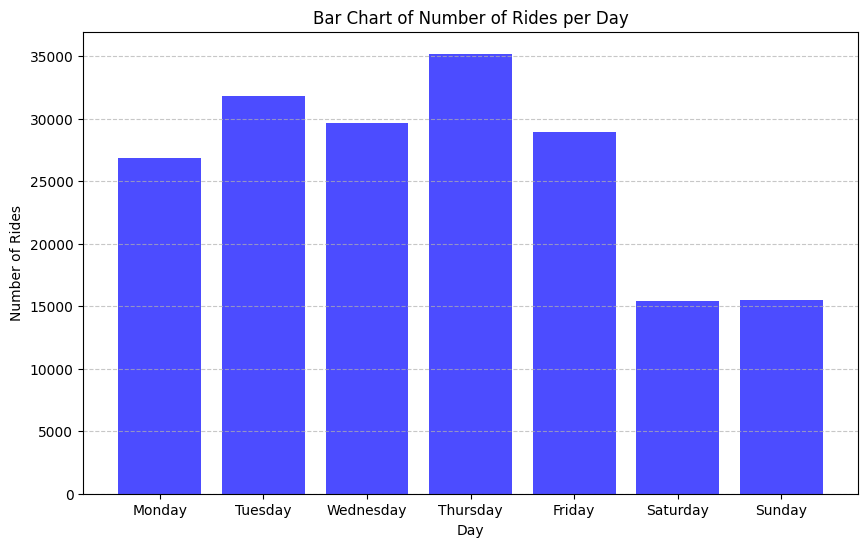

```python
ride_counts = rides_df.groupby('day').size().reset_index(name='number_of_rides')

# Creating the bar chart
plt.figure(figsize=(10, 6))
plt.bar(ride_counts['day'], ride_counts['number_of_rides'], color='blue', alpha=0.7)
plt.title('Bar Chart of Number of Rides per Day')
plt.xlabel('Day')
plt.ylabel('Number of Rides')
plt.grid(axis='y', linestyle='--', alpha=0.7)
plt.show()
```

#### Observation : The highest number of rides were taken on Thursday. Number of rides in the weekend(Saturday and Sunday) is the least

#### Question 5 : How does an individual's age impact the duration of their ride?

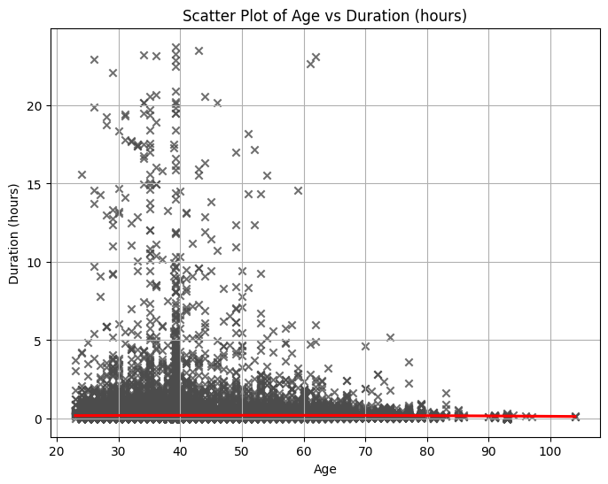

```python
plt.figure(figsize=(8, 6))
sns.regplot(x=rides_df['age'], y=rides_df['duration_hour'],order=2,ci=99,
           marker="x",color=".3",line_kws=dict(color="r"))
plt.title('Scatter Plot of Age vs Duration (hours)')
plt.xlabel('Age')
plt.ylabel('Duration (hours)')
plt.grid(True)
plt.show()
```

#### Question 6 : What is age distribution among gender?

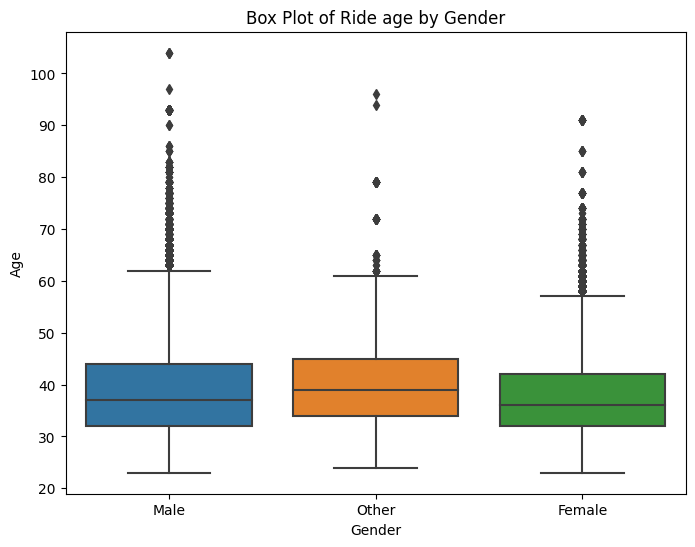

```python
# Box plot of duration_hour by member_gender
plt.figure(figsize=(8, 6))
sns.boxplot(x='member_gender', y='age', data=rides_df)

# Add labels and title
plt.title('Box Plot of Ride age by Gender')
plt.xlabel('Gender')
plt.ylabel('Age')

# Show the plot
plt.show()
```

```python
rides_df['user_type'].unique()
```

```
array(['Customer', 'Subscriber'], dtype=object)
```

### Talk about some of the relationships you observed in this part of the investigation. How did the feature(s) of interest vary with other features in the dataset?

> The highest number of rides were taken on Thursday. Number of rides in the weekend(Saturday and Sunday) is the least

### Did you observe any interesting relationships between the other features (not the main feature(s) of interest)?

> Unsubscribed customer ride bike for long duration compared to subscribed members. I think they use the service when they have long ride only while subscriber use it always even for short rides Number of subscribers are much more than number of guest customers. Looks like the subscription provides members with statisfying privilages

> Number of male subscribers are more than double of number of female subscriber. Riding bikes attract male more than female

## Multivariate Exploration

```python
rides_df.columns
```

```
Index(['duration_sec', 'start_time', 'end_time', 'start_station_id',
       'start_station_name', 'start_station_latitude',
       'start_station_longitude', 'end_station_id', 'end_station_name',
       'end_station_latitude', 'end_station_longitude', 'bike_id', 'user_type',
       'member_birth_year', 'member_gender', 'bike_share_for_all_trip', 'age',
       'age_group', 'duration_hour', 'day'],
      dtype='object')
```

#### Question 7: Is there specific age that are more active on certain days of the week?

#### Is there specific user type that are more active on certain days of the week?

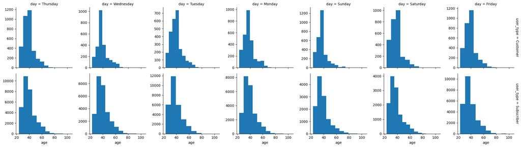

```python
bin_edges = np.arange(-0.5, 24.5 + 1, 1)
g = sns.FacetGrid(data=rides_df, col="day", row="user_type", margin_titles=True, sharey=False)
g.map(plt.hist, 'age', bins=10);
```

### No intresting observation

```python
rides_df.columns
```

```
Index(['duration_sec', 'start_time', 'end_time', 'start_station_id',
       'start_station_name', 'start_station_latitude',
       'start_station_longitude', 'end_station_id', 'end_station_name',
       'end_station_latitude', 'end_station_longitude', 'bike_id', 'user_type',
       'member_birth_year', 'member_gender', 'bike_share_for_all_trip', 'age',
       'age_group', 'duration_hour', 'day'],
      dtype='object')
```

#### Question 8 :How does the average duration of rides differ between genders for each user type (subscribers vs. non-subscribers)?

```python
rides_df['member_gender'].isna().sum()/len(rides_df)
```

```
0.04508017890258536
```

#### 4% of data is of unknown gender. Impute nan values with unspecified

```python
rides_df['member_gender'].fillna('Not Specified', inplace=True)
```

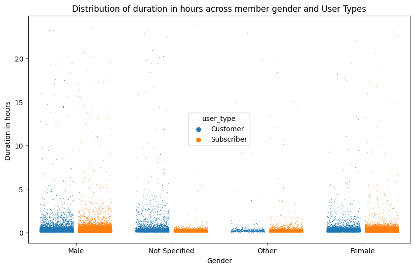

```python
# Create a clustered bar chart using seaborn
plt.figure(figsize=(10, 6))
sns.stripplot(x='member_gender', y='duration_hour', hue='user_type', data=rides_df, dodge=True, jitter=0.35,s=1)

# Add labels and title
plt.xlabel('Gender')
plt.ylabel('Duration in hours ')
plt.title('Distribution of duration in hours across member gender and User Types')
#plt.legend(title='User Type', loc='upper right', bbox_to_anchor=(1, 1))
# Show the plot\

plt.show()
```

#### Observation :Most individuals with unspecified gender are unsbscribed customers. Looks like many non-members don't prefer to provide all their infomation including gender

#### Duration in hours are quite similar for male and female

#### Male subscribers are more than female subscribers

### Question : how distance between start and end location of the ride, age and duration interact with each other across the dataset

```python
# Define the Haversine function
import math
def haversine(lat1, lon1, lat2, lon2):
    # Convert latitude and longitude from degrees to radians
    lat1_rad = math.radians(lat1)
    lon1_rad = math.radians(lon1)
    lat2_rad = math.radians(lat2)
    lon2_rad = math.radians(lon2)

    # Haversine formula
    delta_lat = lat2_rad - lat1_rad
    delta_lon = lon2_rad - lon1_rad

    a = (math.sin(delta_lat / 2) ** 2 +
         math.cos(lat1_rad) * math.cos(lat2_rad) *
         math.sin(delta_lon / 2) ** 2)

    c = 2 * math.asin(math.sqrt(a))

    # Radius of Earth in kilometers
    r = 6371
    distance = r * c

    return distance
```

```python
## Apply the function to calculate the distance
rides_df['distance_km'] = rides_df.apply(
    lambda row: haversine(row['start_station_latitude'],
                           row['start_station_longitude'],
                           row['end_station_latitude'],
                           row['end_station_longitude']), axis=1
)

# Display the updated DataFrame
```

```python
rides_df['distance_km']
```

```
0         0.544709
1         1.742999
2         2.704545
3         0.260739
4         2.409301
            ...
183407    1.464766
183408    1.402716
183409    0.379066
183410    0.747282
183411    0.710395
Name: distance_km, Length: 183340, dtype: float64
```

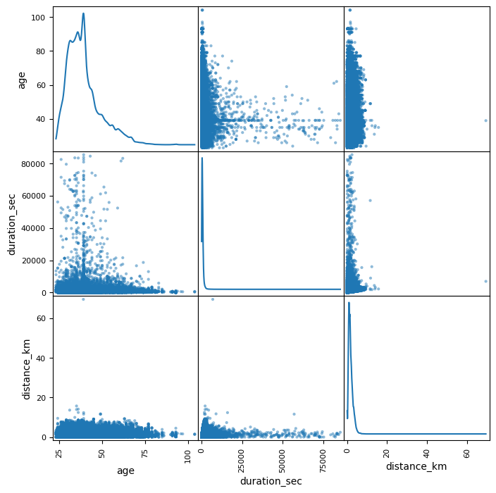

```python
from pandas.plotting import scatter_matrix
sub_rides = rides_df[['age', 'duration_sec','distance_km']]

# Create a scatter plot matrix
scatter_matrix(sub_rides, figsize=(8, 8), diagonal='kde')
plt.show()
```

### Talk about some of the relationships you observed in this part of the investigation. Were there features that strengthened each other in terms of looking at your feature(s) of interest?

> Number of subscriber riders much more than number of unsubscribed customers in all days of the weel Individuals aged around 40 are the most people who ride bikes

### Were there any interesting or surprising interactions between features?

> Most individuals with unspecified gender are unsbscribed customers. Looks like many non-members don't prefer to provide all their infomation including gender

> Sunday and Saturday have the least number of rides

## Conclusions

[output not shown]